# Risk Factor Analysis

## Outcome Variable

**Outcome Variable:** swasted

## Predictor Variables

**Intervention Variable:** parity

**Adjustment Set:**

- arm
- W_mage
- meducyrs
- feducyrs
- hhwealth_quart
- W_mhtcm
- W_mwtkg
- W_mbmi
- vagbrth
- W_nrooms
- impsan
- delta_W_mage
- delta_meducyrs
- delta_feducyrs
- delta_hhwealth_quart
- delta_W_mhtcm
- delta_W_mwtkg
- delta_W_mbmi
- delta_vagbrth
- delta_W_nrooms
- delta_impsan

## Stratifying Variables

The analysis was stratified on these variable(s):

- agecat
- studyid
- country

## Data Summary

| agecat | studyid | country | parity | swasted | n_cell | n |
| --- | --- | --- | --- | --- | --- | --- |
| Birth | ki1000304b-SAS-CompFeed | INDIA | 1 | 0 | 289 | 1103 |
| Birth | ki1000304b-SAS-CompFeed | INDIA | 1 | 1 | 15 | 1103 |
| Birth | ki1000304b-SAS-CompFeed | INDIA | 2 | 0 | 253 | 1103 |
| Birth | ki1000304b-SAS-CompFeed | INDIA | 2 | 1 | 5 | 1103 |
| Birth | ki1000304b-SAS-CompFeed | INDIA | 3+ | 0 | 532 | 1103 |
| Birth | ki1000304b-SAS-CompFeed | INDIA | 3+ | 1 | 9 | 1103 |
| Birth | ki1017093b-PROVIDE | BANGLADESH | 1 | 0 | 194 | 532 |
| Birth | ki1017093b-PROVIDE | BANGLADESH | 1 | 1 | 8 | 532 |
| Birth | ki1017093b-PROVIDE | BANGLADESH | 2 | 0 | 180 | 532 |
| Birth | ki1017093b-PROVIDE | BANGLADESH | 2 | 1 | 2 | 532 |
| Birth | ki1017093b-PROVIDE | BANGLADESH | 3+ | 0 | 145 | 532 |
| Birth | ki1017093b-PROVIDE | BANGLADESH | 3+ | 1 | 3 | 532 |
| Birth | ki1101329-Keneba | GAMBIA | 1 | 0 | 131 | 1338 |
| Birth | ki1101329-Keneba | GAMBIA | 1 | 1 | 15 | 1338 |
| Birth | ki1101329-Keneba | GAMBIA | 2 | 0 | 133 | 1338 |
| Birth | ki1101329-Keneba | GAMBIA | 2 | 1 | 9 | 1338 |
| Birth | ki1101329-Keneba | GAMBIA | 3+ | 0 | 978 | 1338 |
| Birth | ki1101329-Keneba | GAMBIA | 3+ | 1 | 72 | 1338 |
| Birth | ki1113344-GMS-Nepal | NEPAL | 1 | 0 | 174 | 641 |
| Birth | ki1113344-GMS-Nepal | NEPAL | 1 | 1 | 11 | 641 |
| Birth | ki1113344-GMS-Nepal | NEPAL | 2 | 0 | 160 | 641 |
| Birth | ki1113344-GMS-Nepal | NEPAL | 2 | 1 | 9 | 641 |
| Birth | ki1113344-GMS-Nepal | NEPAL | 3+ | 0 | 280 | 641 |
| Birth | ki1113344-GMS-Nepal | NEPAL | 3+ | 1 | 7 | 641 |
| Birth | ki1126311-ZVITAMBO | ZIMBABWE | 1 | 0 | 5154 | 12916 |
| Birth | ki1126311-ZVITAMBO | ZIMBABWE | 1 | 1 | 407 | 12916 |
| Birth | ki1126311-ZVITAMBO | ZIMBABWE | 2 | 0 | 3671 | 12916 |
| Birth | ki1126311-ZVITAMBO | ZIMBABWE | 2 | 1 | 211 | 12916 |
| Birth | ki1126311-ZVITAMBO | ZIMBABWE | 3+ | 0 | 3299 | 12916 |
| Birth | ki1126311-ZVITAMBO | ZIMBABWE | 3+ | 1 | 174 | 12916 |

[output cut: 144 more lines]

The following strata were considered:

- agecat: 24 months, studyid: ki1017093b-PROVIDE, country: BANGLADESH
- agecat: 24 months, studyid: ki1066203-TanzaniaChild2, country: TANZANIA, UNITED REPUBLIC OF
- agecat: 24 months, studyid: ki1101329-Keneba, country: GAMBIA
- agecat: 24 months, studyid: ki1113344-GMS-Nepal, country: NEPAL
- agecat: 24 months, studyid: ki1126311-ZVITAMBO, country: ZIMBABWE
- agecat: 24 months, studyid: ki1135781-COHORTS, country: GUATEMALA
- agecat: 24 months, studyid: ki1135781-COHORTS, country: INDIA
- agecat: 24 months, studyid: ki1135781-COHORTS, country: PHILIPPINES
- agecat: 24 months, studyid: kiGH5241-JiVitA-3, country: BANGLADESH
- agecat: 6 months, studyid: ki1000304b-SAS-CompFeed, country: INDIA
- agecat: 6 months, studyid: ki1000304b-SAS-FoodSuppl, country: INDIA
- agecat: 6 months, studyid: ki1017093b-PROVIDE, country: BANGLADESH
- agecat: 6 months, studyid: ki1066203-TanzaniaChild2, country: TANZANIA, UNITED REPUBLIC OF
- agecat: 6 months, studyid: ki1101329-Keneba, country: GAMBIA
- agecat: 6 months, studyid: ki1113344-GMS-Nepal, country: NEPAL
- agecat: 6 months, studyid: ki1126311-ZVITAMBO, country: ZIMBABWE
- agecat: 6 months, studyid: ki1135781-COHORTS, country: GUATEMALA
- agecat: 6 months, studyid: ki1135781-COHORTS, country: INDIA
- agecat: 6 months, studyid: ki1135781-COHORTS, country: PHILIPPINES
- agecat: 6 months, studyid: kiGH5241-JiVitA-3, country: BANGLADESH
- agecat: Birth, studyid: ki1000304b-SAS-CompFeed, country: INDIA
- agecat: Birth, studyid: ki1017093b-PROVIDE, country: BANGLADESH
- agecat: Birth, studyid: ki1101329-Keneba, country: GAMBIA
- agecat: Birth, studyid: ki1113344-GMS-Nepal, country: NEPAL
- agecat: Birth, studyid: ki1126311-ZVITAMBO, country: ZIMBABWE
- agecat: Birth, studyid: ki1135781-COHORTS, country: GUATEMALA
- agecat: Birth, studyid: ki1135781-COHORTS, country: INDIA
- agecat: Birth, studyid: ki1135781-COHORTS, country: PHILIPPINES
- agecat: Birth, studyid: kiGH5241-JiVitA-3, country: BANGLADESH

### Dropped Strata

Some strata were dropped due to rare outcomes:

- agecat: Birth, studyid: ki1017093b-PROVIDE, country: BANGLADESH
- agecat: 6 months, studyid: ki1000304b-SAS-FoodSuppl, country: INDIA
- agecat: 6 months, studyid: ki1017093b-PROVIDE, country: BANGLADESH
- agecat: 6 months, studyid: ki1066203-TanzaniaChild2, country: TANZANIA, UNITED REPUBLIC OF
- agecat: 6 months, studyid: ki1101329-Keneba, country: GAMBIA
- agecat: 6 months, studyid: ki1113344-GMS-Nepal, country: NEPAL
- agecat: 6 months, studyid: ki1135781-COHORTS, country: GUATEMALA
- agecat: 6 months, studyid: ki1135781-COHORTS, country: PHILIPPINES
- agecat: 24 months, studyid: ki1017093b-PROVIDE, country: BANGLADESH
- agecat: 24 months, studyid: ki1066203-TanzaniaChild2, country: TANZANIA, UNITED REPUBLIC OF
- agecat: 24 months, studyid: ki1101329-Keneba, country: GAMBIA
- agecat: 24 months, studyid: ki1113344-GMS-Nepal, country: NEPAL
- agecat: 24 months, studyid: ki1135781-COHORTS, country: GUATEMALA
- agecat: 24 months, studyid: ki1135781-COHORTS, country: INDIA
- agecat: 24 months, studyid: ki1135781-COHORTS, country: PHILIPPINES

## Methods Detail

We’re interested in the causal parameters $E[Y_a]$ for all values of $a \in \mathcal{A}$. These parameters represent the mean outcome if, possibly contrary to fact, we intervened to set all units to have $A=a$. Under the randomization and positivity assumptions, these are identified by the statistical parameters $\psi_a=E_W[E_{Y|A,W}(Y|A=a,W)]$. In addition, we’re interested in the mean of $Y$, $E[Y]$ under no intervention (the observed mean). We will estimate these parameters by using SuperLearner to fit the relevant likelihood factors – $E_{Y|A,W}(Y|A=a,W)$ and $p(A=a|W)$, and then updating our likelihood fit using a joint TMLE.

For unadjusted analyses ($W=\{\}$), initial likelihoods were estimated using Lrnr_glm to estimate the simple $E(Y|A)$ and Lrnr_mean to estimate $p(A)$. For adjusted analyses, a small library containing Lrnr_glmnet, Lrnr_xgboost, and Lrnr_mean was used.

Having estimated these parameters, we will then use the delta method to estimate relative risks and attributable risks relative to a prespecified baseline level of $A$.

# Results Detail

## Results Plots

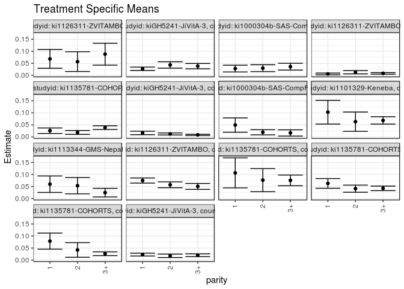

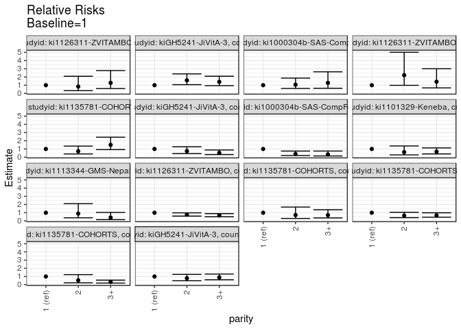

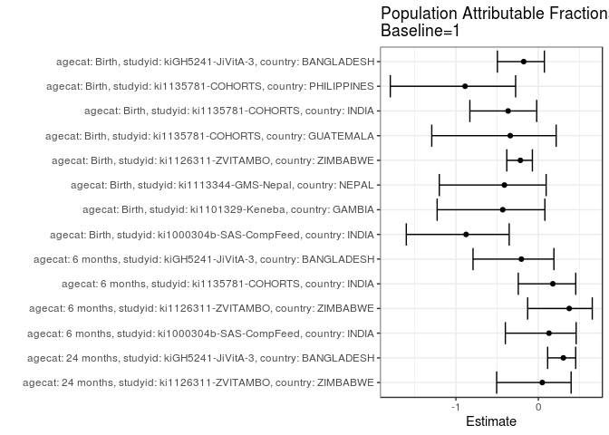

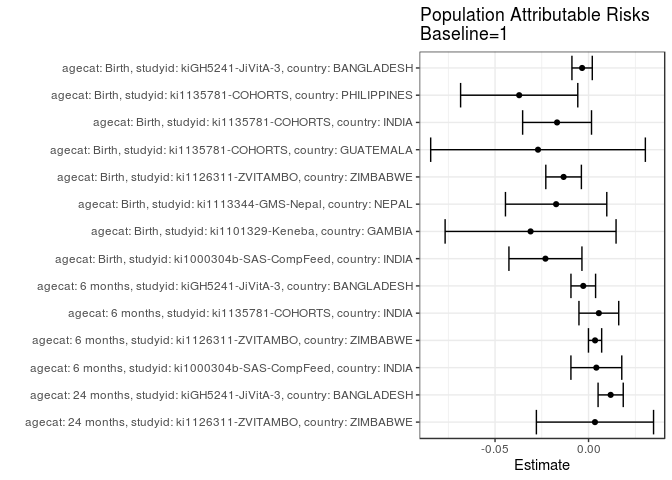

## Results Table

### Parameter: TSM

| agecat | studyid | country | intervention_level | baseline_level | estimate | ci_lower | ci_upper |
| --- | --- | --- | --- | --- | --- | --- | --- |
| Birth | ki1000304b-SAS-CompFeed | INDIA | 1 | NA | 0.0493421 | 0.0195565 | 0.0791278 |
| Birth | ki1000304b-SAS-CompFeed | INDIA | 2 | NA | 0.0193798 | 0.0085871 | 0.0301725 |
| Birth | ki1000304b-SAS-CompFeed | INDIA | 3+ | NA | 0.0166359 | 0.0036649 | 0.0296069 |
| Birth | ki1101329-Keneba | GAMBIA | 1 | NA | 0.1027397 | 0.0534720 | 0.1520074 |
| Birth | ki1101329-Keneba | GAMBIA | 2 | NA | 0.0633803 | 0.0232913 | 0.1034693 |
| Birth | ki1101329-Keneba | GAMBIA | 3+ | NA | 0.0685714 | 0.0532795 | 0.0838634 |
| Birth | ki1113344-GMS-Nepal | NEPAL | 1 | NA | 0.0594595 | 0.0253558 | 0.0935631 |
| Birth | ki1113344-GMS-Nepal | NEPAL | 2 | NA | 0.0532544 | 0.0193748 | 0.0871340 |
| Birth | ki1113344-GMS-Nepal | NEPAL | 3+ | NA | 0.0243902 | 0.0065298 | 0.0422507 |
| Birth | ki1126311-ZVITAMBO | ZIMBABWE | 1 | NA | 0.0746585 | 0.0640403 | 0.0852767 |
| Birth | ki1126311-ZVITAMBO | ZIMBABWE | 2 | NA | 0.0568903 | 0.0447884 | 0.0689922 |
| Birth | ki1126311-ZVITAMBO | ZIMBABWE | 3+ | NA | 0.0502243 | 0.0379814 | 0.0624671 |
| Birth | ki1135781-COHORTS | GUATEMALA | 1 | NA | 0.1063830 | 0.0440119 | 0.1687541 |
| Birth | ki1135781-COHORTS | GUATEMALA | 2 | NA | 0.0762712 | 0.0283479 | 0.1241945 |
| Birth | ki1135781-COHORTS | GUATEMALA | 3+ | NA | 0.0753676 | 0.0531697 | 0.0975656 |
| Birth | ki1135781-COHORTS | INDIA | 1 | NA | 0.0627419 | 0.0426046 | 0.0828791 |
| Birth | ki1135781-COHORTS | INDIA | 2 | NA | 0.0408298 | 0.0260154 | 0.0556443 |
| Birth | ki1135781-COHORTS | INDIA | 3+ | NA | 0.0421971 | 0.0329454 | 0.0514489 |
| Birth | ki1135781-COHORTS | PHILIPPINES | 1 | NA | 0.0788241 | 0.0455061 | 0.1121421 |
| Birth | ki1135781-COHORTS | PHILIPPINES | 2 | NA | 0.0420845 | 0.0117463 | 0.0724226 |
| Birth | ki1135781-COHORTS | PHILIPPINES | 3+ | NA | 0.0263672 | 0.0185740 | 0.0341604 |
| Birth | kiGH5241-JiVitA-3 | BANGLADESH | 1 | NA | 0.0228146 | 0.0169230 | 0.0287062 |
| Birth | kiGH5241-JiVitA-3 | BANGLADESH | 2 | NA | 0.0178235 | 0.0107130 | 0.0249341 |
| Birth | kiGH5241-JiVitA-3 | BANGLADESH | 3+ | NA | 0.0201421 | 0.0142638 | 0.0260204 |
| 6 months | ki1000304b-SAS-CompFeed | INDIA | 1 | NA | 0.0280612 | 0.0140579 | 0.0420646 |
| 6 months | ki1000304b-SAS-CompFeed | INDIA | 2 | NA | 0.0298013 | 0.0154373 | 0.0441654 |
| 6 months | ki1000304b-SAS-CompFeed | INDIA | 3+ | NA | 0.0359375 | 0.0218263 | 0.0500487 |
| 6 months | ki1126311-ZVITAMBO | ZIMBABWE | 1 | NA | 0.0058030 | 0.0021468 | 0.0094592 |
| 6 months | ki1126311-ZVITAMBO | ZIMBABWE | 2 | NA | 0.0128879 | 0.0062219 | 0.0195539 |
| 6 months | ki1126311-ZVITAMBO | ZIMBABWE | 3+ | NA | 0.0082403 | 0.0048937 | 0.0115869 |
| 6 months | ki1135781-COHORTS | INDIA | 1 | NA | 0.0257679 | 0.0143247 | 0.0372111 |
| 6 months | ki1135781-COHORTS | INDIA | 2 | NA | 0.0186406 | 0.0105322 | 0.0267491 |
| 6 months | ki1135781-COHORTS | INDIA | 3+ | NA | 0.0385768 | 0.0309570 | 0.0461966 |
| 6 months | kiGH5241-JiVitA-3 | BANGLADESH | 1 | NA | 0.0165198 | 0.0093922 | 0.0236474 |
| 6 months | kiGH5241-JiVitA-3 | BANGLADESH | 2 | NA | 0.0122889 | 0.0081146 | 0.0164632 |
| 6 months | kiGH5241-JiVitA-3 | BANGLADESH | 3+ | NA | 0.0086544 | 0.0061626 | 0.0111461 |
| 24 months | ki1126311-ZVITAMBO | ZIMBABWE | 1 | NA | 0.0683230 | 0.0293059 | 0.1073400 |
| 24 months | ki1126311-ZVITAMBO | ZIMBABWE | 2 | NA | 0.0569106 | 0.0159212 | 0.0979000 |
| 24 months | ki1126311-ZVITAMBO | ZIMBABWE | 3+ | NA | 0.0878378 | 0.0421819 | 0.1334938 |
| 24 months | kiGH5241-JiVitA-3 | BANGLADESH | 1 | NA | 0.0271122 | 0.0199625 | 0.0342620 |
| 24 months | kiGH5241-JiVitA-3 | BANGLADESH | 2 | NA | 0.0430980 | 0.0297235 | 0.0564725 |
| 24 months | kiGH5241-JiVitA-3 | BANGLADESH | 3+ | NA | 0.0381338 | 0.0269659 | 0.0493017 |

### Parameter: E(Y)

| agecat | studyid | country | intervention_level | baseline_level | estimate | ci_lower | ci_upper |
| --- | --- | --- | --- | --- | --- | --- | --- |
| Birth | ki1000304b-SAS-CompFeed | INDIA | NA | NA | 0.0262919 | 0.0122874 | 0.0402964 |
| Birth | ki1101329-Keneba | GAMBIA | NA | NA | 0.0717489 | 0.0579157 | 0.0855821 |
| Birth | ki1113344-GMS-Nepal | NEPAL | NA | NA | 0.0421217 | 0.0265597 | 0.0576837 |
| Birth | ki1126311-ZVITAMBO | ZIMBABWE | NA | NA | 0.0613193 | 0.0571816 | 0.0654570 |
| Birth | ki1135781-COHORTS | GUATEMALA | NA | NA | 0.0793651 | 0.0600839 | 0.0986462 |
| Birth | ki1135781-COHORTS | INDIA | NA | NA | 0.0459144 | 0.0393065 | 0.0525222 |
| Birth | ki1135781-COHORTS | PHILIPPINES | NA | NA | 0.0417385 | 0.0344572 | 0.0490198 |
| Birth | kiGH5241-JiVitA-3 | BANGLADESH | NA | NA | 0.0193738 | 0.0169653 | 0.0217823 |
| 6 months | ki1000304b-SAS-CompFeed | INDIA | NA | NA | 0.0322339 | 0.0235219 | 0.0409459 |
| 6 months | ki1126311-ZVITAMBO | ZIMBABWE | NA | NA | 0.0092897 | 0.0072507 | 0.0113288 |
| 6 months | ki1135781-COHORTS | INDIA | NA | NA | 0.0312719 | 0.0260599 | 0.0364838 |
| 6 months | kiGH5241-JiVitA-3 | BANGLADESH | NA | NA | 0.0137035 | 0.0116269 | 0.0157801 |
| 24 months | ki1126311-ZVITAMBO | ZIMBABWE | NA | NA | 0.0717593 | 0.0473936 | 0.0961250 |
| 24 months | kiGH5241-JiVitA-3 | BANGLADESH | NA | NA | 0.0389399 | 0.0346167 | 0.0432631 |

### Parameter: RR

| agecat | studyid | country | intervention_level | baseline_level | estimate | ci_lower | ci_upper |
| --- | --- | --- | --- | --- | --- | --- | --- |
| Birth | ki1000304b-SAS-CompFeed | INDIA | 1 | 1 | 1.0000000 | 1.0000000 | 1.0000000 |
| Birth | ki1000304b-SAS-CompFeed | INDIA | 2 | 1 | 0.3927649 | 0.2076508 | 0.7429023 |
| Birth | ki1000304b-SAS-CompFeed | INDIA | 3+ | 1 | 0.3371534 | 0.1521067 | 0.7473205 |
| Birth | ki1101329-Keneba | GAMBIA | 1 | 1 | 1.0000000 | 1.0000000 | 1.0000000 |
| Birth | ki1101329-Keneba | GAMBIA | 2 | 1 | 0.6169014 | 0.2789306 | 1.3643800 |
| Birth | ki1101329-Keneba | GAMBIA | 3+ | 1 | 0.6674286 | 0.3933010 | 1.1326209 |
| Birth | ki1113344-GMS-Nepal | NEPAL | 1 | 1 | 1.0000000 | 1.0000000 | 1.0000000 |
| Birth | ki1113344-GMS-Nepal | NEPAL | 2 | 1 | 0.8956428 | 0.3803066 | 2.1092877 |
| Birth | ki1113344-GMS-Nepal | NEPAL | 3+ | 1 | 0.4101996 | 0.1618193 | 1.0398242 |
| Birth | ki1126311-ZVITAMBO | ZIMBABWE | 1 | 1 | 1.0000000 | 1.0000000 | 1.0000000 |
| Birth | ki1126311-ZVITAMBO | ZIMBABWE | 2 | 1 | 0.7620066 | 0.5899607 | 0.9842250 |
| Birth | ki1126311-ZVITAMBO | ZIMBABWE | 3+ | 1 | 0.6727195 | 0.5072960 | 0.8920857 |
| Birth | ki1135781-COHORTS | GUATEMALA | 1 | 1 | 1.0000000 | 1.0000000 | 1.0000000 |
| Birth | ki1135781-COHORTS | GUATEMALA | 2 | 1 | 0.7169492 | 0.3035745 | 1.6932122 |
| Birth | ki1135781-COHORTS | GUATEMALA | 3+ | 1 | 0.7084559 | 0.3675932 | 1.3653943 |
| Birth | ki1135781-COHORTS | INDIA | 1 | 1 | 1.0000000 | 1.0000000 | 1.0000000 |
| Birth | ki1135781-COHORTS | INDIA | 2 | 1 | 0.6507591 | 0.4008912 | 1.0563649 |
| Birth | ki1135781-COHORTS | INDIA | 3+ | 1 | 0.6725514 | 0.4559506 | 0.9920491 |
| Birth | ki1135781-COHORTS | PHILIPPINES | 1 | 1 | 1.0000000 | 1.0000000 | 1.0000000 |
| Birth | ki1135781-COHORTS | PHILIPPINES | 2 | 1 | 0.5339034 | 0.2314866 | 1.2314014 |
| Birth | ki1135781-COHORTS | PHILIPPINES | 3+ | 1 | 0.3345070 | 0.1997197 | 0.5602599 |
| Birth | kiGH5241-JiVitA-3 | BANGLADESH | 1 | 1 | 1.0000000 | 1.0000000 | 1.0000000 |
| Birth | kiGH5241-JiVitA-3 | BANGLADESH | 2 | 1 | 0.7812330 | 0.4837978 | 1.2615291 |
| Birth | kiGH5241-JiVitA-3 | BANGLADESH | 3+ | 1 | 0.8828613 | 0.5992568 | 1.3006844 |
| 6 months | ki1000304b-SAS-CompFeed | INDIA | 1 | 1 | 1.0000000 | 1.0000000 | 1.0000000 |
| 6 months | ki1000304b-SAS-CompFeed | INDIA | 2 | 1 | 1.0620108 | 0.6052683 | 1.8634168 |
| 6 months | ki1000304b-SAS-CompFeed | INDIA | 3+ | 1 | 1.2806818 | 0.6228782 | 2.6331726 |
| 6 months | ki1126311-ZVITAMBO | ZIMBABWE | 1 | 1 | 1.0000000 | 1.0000000 | 1.0000000 |
| 6 months | ki1126311-ZVITAMBO | ZIMBABWE | 2 | 1 | 2.2208935 | 0.9829169 | 5.0180926 |
| 6 months | ki1126311-ZVITAMBO | ZIMBABWE | 3+ | 1 | 1.4200009 | 0.6710206 | 3.0049784 |
| 6 months | ki1135781-COHORTS | INDIA | 1 | 1 | 1.0000000 | 1.0000000 | 1.0000000 |
| 6 months | ki1135781-COHORTS | INDIA | 2 | 1 | 0.7234059 | 0.3885196 | 1.3469490 |
| 6 months | ki1135781-COHORTS | INDIA | 3+ | 1 | 1.4970876 | 0.9208279 | 2.4339741 |
| 6 months | kiGH5241-JiVitA-3 | BANGLADESH | 1 | 1 | 1.0000000 | 1.0000000 | 1.0000000 |
| 6 months | kiGH5241-JiVitA-3 | BANGLADESH | 2 | 1 | 0.7438898 | 0.4366964 | 1.2671777 |
| 6 months | kiGH5241-JiVitA-3 | BANGLADESH | 3+ | 1 | 0.5238787 | 0.3140980 | 0.8737683 |
| 24 months | ki1126311-ZVITAMBO | ZIMBABWE | 1 | 1 | 1.0000000 | 1.0000000 | 1.0000000 |
| 24 months | ki1126311-ZVITAMBO | ZIMBABWE | 2 | 1 | 0.8329638 | 0.3322286 | 2.0884073 |
| 24 months | ki1126311-ZVITAMBO | ZIMBABWE | 3+ | 1 | 1.2856265 | 0.5939568 | 2.7827538 |
| 24 months | kiGH5241-JiVitA-3 | BANGLADESH | 1 | 1 | 1.0000000 | 1.0000000 | 1.0000000 |
| 24 months | kiGH5241-JiVitA-3 | BANGLADESH | 2 | 1 | 1.5896144 | 1.0638965 | 2.3751125 |
| 24 months | kiGH5241-JiVitA-3 | BANGLADESH | 3+ | 1 | 1.4065166 | 0.9440991 | 2.0954251 |

### Parameter: PAR

| agecat | studyid | country | intervention_level | baseline_level | estimate | ci_lower | ci_upper |
| --- | --- | --- | --- | --- | --- | --- | --- |
| Birth | ki1000304b-SAS-CompFeed | INDIA | 1 | NA | -0.0230502 | -0.0425694 | -0.0035310 |
| Birth | ki1101329-Keneba | GAMBIA | 1 | NA | -0.0309908 | -0.0766958 | 0.0147141 |
| Birth | ki1113344-GMS-Nepal | NEPAL | 1 | NA | -0.0173378 | -0.0444282 | 0.0097526 |
| Birth | ki1126311-ZVITAMBO | ZIMBABWE | 1 | NA | -0.0133392 | -0.0228521 | -0.0038263 |
| Birth | ki1135781-COHORTS | GUATEMALA | 1 | NA | -0.0270179 | -0.0844158 | 0.0303800 |
| Birth | ki1135781-COHORTS | INDIA | 1 | NA | -0.0168275 | -0.0352437 | 0.0015887 |
| Birth | ki1135781-COHORTS | PHILIPPINES | 1 | NA | -0.0370856 | -0.0684175 | -0.0057536 |
| Birth | kiGH5241-JiVitA-3 | BANGLADESH | 1 | NA | -0.0034408 | -0.0088814 | 0.0019999 |
| 6 months | ki1000304b-SAS-CompFeed | INDIA | 1 | NA | 0.0041727 | -0.0094235 | 0.0177689 |
| 6 months | ki1126311-ZVITAMBO | ZIMBABWE | 1 | NA | 0.0034867 | -0.0000414 | 0.0070148 |
| 6 months | ki1135781-COHORTS | INDIA | 1 | NA | 0.0055040 | -0.0051308 | 0.0161387 |
| 6 months | kiGH5241-JiVitA-3 | BANGLADESH | 1 | NA | -0.0028163 | -0.0094015 | 0.0037690 |
| 24 months | ki1126311-ZVITAMBO | ZIMBABWE | 1 | NA | 0.0034363 | -0.0278897 | 0.0347623 |
| 24 months | kiGH5241-JiVitA-3 | BANGLADESH | 1 | NA | 0.0118277 | 0.0050992 | 0.0185562 |

### Parameter: PAF

| agecat | studyid | country | intervention_level | baseline_level | estimate | ci_lower | ci_upper |
| --- | --- | --- | --- | --- | --- | --- | --- |
| Birth | ki1000304b-SAS-CompFeed | INDIA | 1 | NA | -0.8767014 | -1.6019224 | -0.3536177 |
| Birth | ki1101329-Keneba | GAMBIA | 1 | NA | -0.4319349 | -1.2275847 | 0.0795243 |
| Birth | ki1113344-GMS-Nepal | NEPAL | 1 | NA | -0.4116116 | -1.2013007 | 0.0947864 |
| Birth | ki1126311-ZVITAMBO | ZIMBABWE | 1 | NA | -0.2175374 | -0.3826937 | -0.0721082 |
| Birth | ki1135781-COHORTS | GUATEMALA | 1 | NA | -0.3404255 | -1.2928794 | 0.2163824 |
| Birth | ki1135781-COHORTS | INDIA | 1 | NA | -0.3664969 | -0.8307251 | -0.0199859 |
| Birth | ki1135781-COHORTS | PHILIPPINES | 1 | NA | -0.8885213 | -1.7959345 | -0.2756066 |
| Birth | kiGH5241-JiVitA-3 | BANGLADESH | 1 | NA | -0.1775995 | -0.4965745 | 0.0733902 |
| 6 months | ki1000304b-SAS-CompFeed | INDIA | 1 | NA | 0.1294495 | -0.4000328 | 0.4586853 |
| 6 months | ki1126311-ZVITAMBO | ZIMBABWE | 1 | NA | 0.3753297 | -0.1296087 | 0.6545592 |
| 6 months | ki1135781-COHORTS | INDIA | 1 | NA | 0.1760043 | -0.2431695 | 0.4538404 |
| 6 months | kiGH5241-JiVitA-3 | BANGLADESH | 1 | NA | -0.2055138 | -0.7921456 | 0.1890930 |
| 24 months | ki1126311-ZVITAMBO | ZIMBABWE | 1 | NA | 0.0478862 | -0.5055473 | 0.3978796 |
| 24 months | kiGH5241-JiVitA-3 | BANGLADESH | 1 | NA | 0.3037416 | 0.1129926 | 0.4534704 |